# linear_algebra

```python
import numpy as np
ar1 = np.array([2,3,5,7,0])
ar1
```

```
array([2, 3, 5, 7, 0])
```

```python
ar1.T  # column vector is transponse of row vector
```

```
array([2, 3, 5, 7, 0])
```

```python
ar2 = np.arange(0,4,0.2) # equally spaced sequence from 0 (included) to 4 (excluded) with 0.2 as step size
print (ar2)
```

```
[0.  0.2 0.4 0.6 0.8 1.  1.2 1.4 1.6 1.8 2.  2.2 2.4 2.6 2.8 3.  3.2 3.4
 3.6 3.8]
```

```python
ar3 = np.zeros(6)
print (ar3)
ar4 = np.ones(10)
print (ar4)
ar5 = np.random.random(6)
print (ar5)
```

```
[0. 0. 0. 0. 0. 0.]
[1. 1. 1. 1. 1. 1. 1. 1. 1. 1.]
[0.70480056 0.86179271 0.85151207 0.585055   0.07058307 0.25477462]
```

```python
print(ar5.size)
print(ar5.dtype)
```

```
6
float64
```

```python
n = np.arange(11)
fn = 2*n**3 + 3*n - 4
print (fn)
```

```
[  -4    1   18   59  136  261  446  703 1044 1481 2026]
```

```python
f = 1 #Hz
t = np.arange(0,1,0.01)
y = 5*np.sin(2*np.pi*f*t)
```

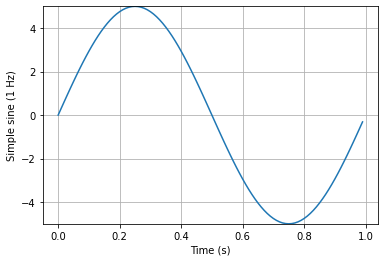

```python
import matplotlib.pyplot as plt
%matplotlib inline
plt.plot(t,y)
plt.grid()
plt.xlabel('Time (s)')
plt.ylabel('Simple sine (1 Hz)')
plt.ylim(-5,5)
plt.show()
```

```python
print(np.mean(y)) # should be close to 0.
print(np.max(y) - np.min(y)) # amplitude
print(np.std(y)) # rms value : Root of Meand of Square of the signal= approximation DC current to AC signal.
```

```
1.0547118733938987e-17
10.0
3.5355339059327378
```

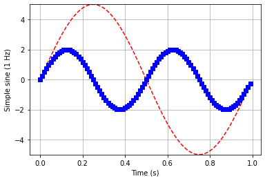

```python
f1 = 1 #Hz
f2 = 2 #Hz
t = np.arange(0,1,0.01)
y1 = 5*np.sin(2*np.pi*f1*t)
y2 = 2*np.sin(2*np.pi*f2*t)
import matplotlib.pyplot as plt
%matplotlib inline
plt.plot(t,y1,'r--', t, y2,'bs')
plt.grid()
plt.xlabel('Time (s)')
plt.ylabel('Simple sine (1 Hz)')
plt.ylim(-5,5)
plt.show()
```

# Exercise 1

How many complete cycles in one second?

What is V rms value of the signal?

What is average value of the signal?

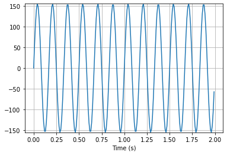

```python
f = 6
t = np.arange(0, 2, 0.01)
vmax = 110 * 2**(1/2)
v = np.sin(2 * np.pi * f * t) * vmax
import matplotlib.pyplot as plt
%matplotlib inline
plt.plot(t, v)
plt.grid()
plt.xlabel('Time (s)')
plt.ylim(-vmax, vmax)
plt.show()
```

```python
print(np.std(v)) # -> 110
print(np.mean(v)) # -> 0
```

```
109.99999999999997
2.5579538487363606e-15
```

```python
mat1 = np.array([[3,4,1],[3,6,1]])
mat1
```

```
array([[3, 4, 1],
       [3, 6, 1]])
```

```python
mat1.shape # 1st dimension is number of rows, 2nd dimension is number of cols
```

```
(2, 3)
```

```python
mat1.ndim
```

```
2
```

```python
mat2 = np.ones((4,3))
mat2
```

```
array([[1., 1., 1.],
       [1., 1., 1.],
       [1., 1., 1.],
       [1., 1., 1.]])
```

```python
mat3 = np.random.random(mat2.shape)
print (mat3)
```

```
[[0.24411799 0.40051115 0.87041166]
 [0.59272467 0.86611787 0.550511  ]
 [0.2269878  0.59701872 0.99579396]
 [0.90464862 0.39694552 0.2830986 ]]
```

```python
mat4 = np.arange(10).reshape((2,5))
mat4
```

```
array([[0, 1, 2, 3, 4],
       [5, 6, 7, 8, 9]])
```

```python
s=2 # scalar value
A=np.array([[1, 2], [4,5]])
s * A    #
```

```
array([[ 2,  4],
       [ 8, 10]])
```

```python
I = np.array([[1, 0], [0, 1]])
I
```

```
array([[1, 0],
       [0, 1]])
```

```python
A=np.array([[1, 2], [4,5]])
A
```

```
array([[1, 2],
       [4, 5]])
```

```python
A @ I
```

```
array([[1, 2],
       [4, 5]])
```

```python
v = np.array([[1],[2]])
A=np.array([[1, 2], [4,5]])
A @ v
```

```
array([[ 5],
       [14]])
```

```python
a = 5
a**-1
A=np.array([[2, 3], [5,1]])
A_inv = np.linalg.inv(A)
print(A)
print(A_inv)
y= A @ A_inv
print(y) # -> I
```

```
[[2 3]
 [5 1]]
[[-0.07692308  0.23076923]
 [ 0.38461538 -0.15384615]]
[[ 1.00000000e+00 -5.55111512e-17]
 [-5.55111512e-17  1.00000000e+00]]
```

# Exercise 2

Create A matrix dimension (2x2)

Given \begin{bmatrix} 2 & 3\\ 5 & 1 \end{bmatrix}

```python
a = np.array([[2, 3], [5, 1]])
a_inv = np.linalg.inv(a)
a @ a_inv # -> I2
```

```
array([[ 1.00000000e+00, -5.55111512e-17],
       [-5.55111512e-17,  1.00000000e+00]])
```

```python
Python /np.ones?
```

```python
import numpy as np
A = np.array([[2,3],
            [5, 1]])
b = np.array([[8,2]]).T
A_inv = np.linalg.inv(A)    # let compute inverse matrix for A
x = A_inv.dot(b)    # Multiple Matrix in numpy
```

```python
x
```

```
array([[-0.15384615],
       [ 2.76923077]])
```

```python
A.dot(x)- b   # Verify answer
```

```
array([[-8.8817842e-16],
       [-4.4408921e-16]])
```

# Exercise 3

You are running a concession stand at a university soccer game. You are selling hot dogs and sodas. Each hot dog costs 19 baht and each soda costs 35 baht. At the end of the night you made a total of 3670 baht.

You sold a total of 130 hot dogs and sodas combined. You must report the number of hot dogs sold and the number of sodas sold. How many hot dogs were sold and how many sodas were sold?

Instruction:

Create Matrix of the system equation represent this problem: Matrix A.

Compute inverse of A

Find out x

Verify your solution is correct.

```python
# h + s = 130
# 19h + 35s = 3670
A = np.array([[ 1,  1],
              [19, 35]])

B = np.array([130, 3670])
A_inv = np.linalg.inv(A)
x = A_inv @ B
print(x)
```

```
[55. 75.]
```

```python
A.dot(x) - B   # Verify answer
```

```
array([0., 0.])
```

```python
import numpy as np
A = np.array([[2.,3.],
            [5., 1.]])
b = np.array([[8.,2.]]).T
A_inv = np.linalg.inv(A)
x = A_inv @ b
```

```python
x
```

```
array([[-0.15384615],
       [ 2.76923077]])
```

```python
A_inv
```

```
array([[-0.07692308,  0.23076923],
       [ 0.38461538, -0.15384615]])
```

```
x is  [[-0.15384615  2.76923077]]  and b is  [[8. 2.]]
```

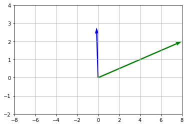

```python
import matplotlib.pyplot as plt

x_position = [0, 0]   # vector x and b start at origin
y_position = [0, 0]

x_direction =[x[0], b[0]] # List of Endpoint of Arrow for x
y_direction = [x[1], b[1]]

plt.quiver(x_position, y_position, x_direction, y_direction, angles='xy',scale_units='xy', scale=1,color=['b','g'])
plt.xlim(-8,8)
plt.ylim(-2,4)

plt.grid()   #<-- plot grid lines

# vector x is blue,and vector b is green
print('x is ',x.T,  ' and b is ',b.T )  # for check member of vectors, easy to read
```

# Exercise 4

Verify the matrix (A−1) can translate vector b back to vector x

Proof: \begin{align} A^{−1}b=x \end{align} using Python numpy and plt.quiver

```
[[2. 3.]
 [5. 1.]]
[[-0.07692308  0.23076923]
 [ 0.38461538 -0.15384615]]
```

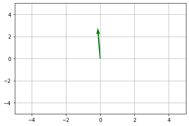

```python
import matplotlib.pyplot as plt

sudo_x = A_inv @ b # this one come from linear transformation.

assert (sudo_x == x).all() # which get the same as x

plt.quiver(0, 0, sudo_x[0], sudo_x[1], angles='xy',scale_units='xy', scale=1,color='g')


plt.xlim(-5, 5)
plt.ylim(-5, 5)

plt.grid()   #<-- plot grid lines

# vector x is blue,and vector b is green
print(A)
print(A_inv)
```

```python
import numpy as np
import matplotlib.pyplot as plt

A = np.array([[6,5],
            [1, 2]])
```

```python
u1 = np.array([[1,0]]).T;               print('A*u1= \n', A.dot(u1))
u2 = np.array([[0, 1]]).T;               print('A*u2= \n', A.dot(u2))
```

```
A*u1=
 [[6]
 [1]]
A*u2=
 [[5]
 [2]]
```

```
u1 =  [[1]
 [0]]
A *u =  [[6]
 [1]]
```

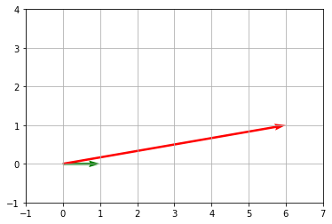

```python
x_position = [0, 0]   # vector x and b start at origin
y_position = [0, 0]

Au1 = A @ u1

x_direction = [u1[0], Au1[0]] # List of Endpoint of Arrow for x
y_direction = [u1[1], Au1[1]]

plt.quiver(x_position, y_position, x_direction, y_direction, angles='xy',scale_units='xy', scale=1,color=['g','r'])
plt.xlim(-1,7)
plt.ylim(-1,4)
plt.grid(b=True, which='major') #<-- plot grid lines
print('u1 = ', u1); print('A *u = ', Au1)
```

```
u2 =  [[0]
 [1]]
A *u =  [[5]
 [2]]
```

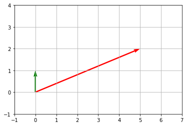

```python
x_position = [0, 0]   # vector x and b start at origin
y_position = [0, 0]

Au2 = A @ u2

x_direction = [u2[0], Au2[0]] # List of Endpoint of Arrow for x
y_direction = [u2[1], Au2[1]]

plt.quiver(x_position, y_position, x_direction, y_direction, angles='xy',scale_units='xy', scale=1,color=['g','r'])
plt.xlim(-1,7)
plt.ylim(-1,4)
plt.grid(b=True, which='major') #<-- plot grid lines
print('u2 = ', u2); print('A *u = ', Au2)
```

```python
import numpy as np
import matplotlib.pyplot as plt

A = np.array([[6,5],
            [1, 2]])

eigvals, eigvecs = np.linalg.eig(A)
u = eigvecs[:,0]
lamda = eigvals[0]

Au = A @ u
lamda_u = lamda * u
```

```
u =  [0.98058068 0.19611614]
lamda *u =  [6.86406473 1.37281295]
```

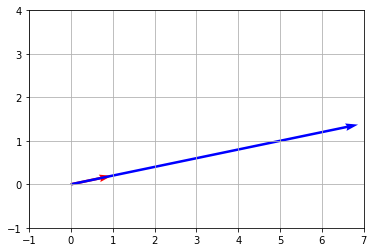

```python
x_position = [0, 0]   # vector x and b start at origin
y_position = [0, 0]

x_direction =[u[0], lamda_u[0]] # List of Endpoint of Arrow for x
y_direction = [u[1], lamda_u[1]]

plt.quiver(x_position, y_position, x_direction, y_direction, angles='xy',scale_units='xy', scale=1,color=['r','b'])
plt.xlim(-1,7)
plt.ylim(-1,4)
plt.grid(b=True, which='major') #<-- plot grid lines
print('u = ', u); print('lamda *u = ', lamda_u)
```

# Exercise 5

```python
A = np.array([[6,5],
            [1, 2]])

eigvals, eigvecs = np.linalg.eig(A)
print(eigvals)
print(eigvecs)
```

```
[7. 1.]
[[ 0.98058068 -0.70710678]
 [ 0.19611614  0.70710678]]
```

```python
u = eigvecs[:, 0]
l = eigvals[0]
assert (A @ u == l * u).all()
```

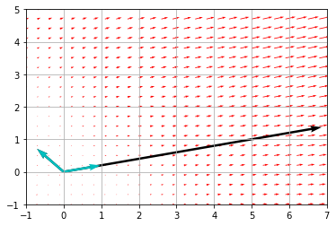

```python
x = np.arange(-1,7.2,0.3)
y = np.arange(-1,7.2,0.3)

Z = np.meshgrid(x, y)
Z = np.array(Z)
Z = Z.reshape(2, x.shape[0] * y.shape[0])
o = np.tensordot(A, Z, axes=1)

plt.quiver(Z[0], Z[1], o[0], o[1], angles='xy',scale_units='xy', color="r")

for l, v in zip(eigvals, eigvecs.T):
    plt.quiver(0, 0, l*v[0], l*v[1], angles='xy',scale_units='xy', scale=1)
    plt.quiver(0, 0, v[0], v[1], angles='xy',scale_units='xy', scale=1, color="c")


plt.xlim(-1, 7)
plt.ylim(-1, 5)
plt.grid()
```

```python
eigvecs[0, 0], eigvecs[1, 0]
```

```
(0.9805806756909201, 0.19611613513818404)
```

```python
x = np.arange(0,2.2,0.2)
y = np.arange(0,2.2,0.2)

X, Y = np.meshgrid(x, y)
```

```python
x = np.arange(0,2.2,0.2)
y = np.arange(0,2.2,0.2)

Z = np.meshgrid(x, y)
Z = np.array(Z)
Z = Z.reshape(2, 121)
```

```python
o = np.tensordot(A, Z, axes=1)
```

```python
Z
```

```
array([[0. , 0.2, 0.4, 0.6, 0.8, 1. , 1.2, 1.4, 1.6, 1.8, 2. , 0. , 0.2,
        0.4, 0.6, 0.8, 1. , 1.2, 1.4, 1.6, 1.8, 2. , 0. , 0.2, 0.4, 0.6,
        0.8, 1. , 1.2, 1.4, 1.6, 1.8, 2. , 0. , 0.2, 0.4, 0.6, 0.8, 1. ,
        1.2, 1.4, 1.6, 1.8, 2. , 0. , 0.2, 0.4, 0.6, 0.8, 1. , 1.2, 1.4,
        1.6, 1.8, 2. , 0. , 0.2, 0.4, 0.6, 0.8, 1. , 1.2, 1.4, 1.6, 1.8,
        2. , 0. , 0.2, 0.4, 0.6, 0.8, 1. , 1.2, 1.4, 1.6, 1.8, 2. , 0. ,
        0.2, 0.4, 0.6, 0.8, 1. , 1.2, 1.4, 1.6, 1.8, 2. , 0. , 0.2, 0.4,
        0.6, 0.8, 1. , 1.2, 1.4, 1.6, 1.8, 2. , 0. , 0.2, 0.4, 0.6, 0.8,
        1. , 1.2, 1.4, 1.6, 1.8, 2. , 0. , 0.2, 0.4, 0.6, 0.8, 1. , 1.2,
        1.4, 1.6, 1.8, 2. ],
       [0. , 0. , 0. , 0. , 0. , 0. , 0. , 0. , 0. , 0. , 0. , 0.2, 0.2,
        0.2, 0.2, 0.2, 0.2, 0.2, 0.2, 0.2, 0.2, 0.2, 0.4, 0.4, 0.4, 0.4,
        0.4, 0.4, 0.4, 0.4, 0.4, 0.4, 0.4, 0.6, 0.6, 0.6, 0.6, 0.6, 0.6,
        0.6, 0.6, 0.6, 0.6, 0.6, 0.8, 0.8, 0.8, 0.8, 0.8, 0.8, 0.8, 0.8,
        0.8, 0.8, 0.8, 1. , 1. , 1. , 1. , 1. , 1. , 1. , 1. , 1. , 1. ,
        1. , 1.2, 1.2, 1.2, 1.2, 1.2, 1.2, 1.2, 1.2, 1.2, 1.2, 1.2, 1.4,
        1.4, 1.4, 1.4, 1.4, 1.4, 1.4, 1.4, 1.4, 1.4, 1.4, 1.6, 1.6, 1.6,
        1.6, 1.6, 1.6, 1.6, 1.6, 1.6, 1.6, 1.6, 1.8, 1.8, 1.8, 1.8, 1.8,
        1.8, 1.8, 1.8, 1.8, 1.8, 1.8, 2. , 2. , 2. , 2. , 2. , 2. , 2. ,
        2. , 2. , 2. , 2. ]])
```

```python
o
```

```
array([[ 0. ,  1.2,  2.4,  3.6,  4.8,  6. ,  7.2,  8.4,  9.6, 10.8, 12. ,
         1. ,  2.2,  3.4,  4.6,  5.8,  7. ,  8.2,  9.4, 10.6, 11.8, 13. ,
         2. ,  3.2,  4.4,  5.6,  6.8,  8. ,  9.2, 10.4, 11.6, 12.8, 14. ,
         3. ,  4.2,  5.4,  6.6,  7.8,  9. , 10.2, 11.4, 12.6, 13.8, 15. ,
         4. ,  5.2,  6.4,  7.6,  8.8, 10. , 11.2, 12.4, 13.6, 14.8, 16. ,
         5. ,  6.2,  7.4,  8.6,  9.8, 11. , 12.2, 13.4, 14.6, 15.8, 17. ,
         6. ,  7.2,  8.4,  9.6, 10.8, 12. , 13.2, 14.4, 15.6, 16.8, 18. ,
         7. ,  8.2,  9.4, 10.6, 11.8, 13. , 14.2, 15.4, 16.6, 17.8, 19. ,
         8. ,  9.2, 10.4, 11.6, 12.8, 14. , 15.2, 16.4, 17.6, 18.8, 20. ,
         9. , 10.2, 11.4, 12.6, 13.8, 15. , 16.2, 17.4, 18.6, 19.8, 21. ,
        10. , 11.2, 12.4, 13.6, 14.8, 16. , 17.2, 18.4, 19.6, 20.8, 22. ],
       [ 0. ,  0.2,  0.4,  0.6,  0.8,  1. ,  1.2,  1.4,  1.6,  1.8,  2. ,
         0.4,  0.6,  0.8,  1. ,  1.2,  1.4,  1.6,  1.8,  2. ,  2.2,  2.4,
         0.8,  1. ,  1.2,  1.4,  1.6,  1.8,  2. ,  2.2,  2.4,  2.6,  2.8,
         1.2,  1.4,  1.6,  1.8,  2. ,  2.2,  2.4,  2.6,  2.8,  3. ,  3.2,
         1.6,  1.8,  2. ,  2.2,  2.4,  2.6,  2.8,  3. ,  3.2,  3.4,  3.6,
         2. ,  2.2,  2.4,  2.6,  2.8,  3. ,  3.2,  3.4,  3.6,  3.8,  4. ,
         2.4,  2.6,  2.8,  3. ,  3.2,  3.4,  3.6,  3.8,  4. ,  4.2,  4.4,
         2.8,  3. ,  3.2,  3.4,  3.6,  3.8,  4. ,  4.2,  4.4,  4.6,  4.8,
         3.2,  3.4,  3.6,  3.8,  4. ,  4.2,  4.4,  4.6,  4.8,  5. ,  5.2,
         3.6,  3.8,  4. ,  4.2,  4.4,  4.6,  4.8,  5. ,  5.2,  5.4,  5.6,
         4. ,  4.2,  4.4,  4.6,  4.8,  5. ,  5.2,  5.4,  5.6,  5.8,  6. ]])
```